# A3: Additional Exploratory Data Analysis (EDA)

# Setup

#### Using R Markdown

Again for this assignment we will be using R Markdown.

**Action:**

Download the **A3_EDA_Template.Rmd** file from **[Canvas](https://clemson.instructure.com/courses/237270/files/23504741/download?download_frd=1)** or the **[Box Folder](https://clemson.box.com/s/mh6fx9wmasiqxxeufl7kmt73lo2rjdgt)** to your computer.

**Action:**

Copy the **A3_EDA_Template.Rmd** file from wherever you downloaded the file (typically the Downloads folder) into your project folder. You don’t want to be editing the file in your downloads folder.

**This is important - DON’T SKIP THIS STEP**

**Action:**

Navigate to your project folder and double click on the .Rmd file. This will open the **A3_EDA_Template.Rmd** in RStudio.

**Action:**

At the top of the file (3rd line down) change the text **YOUR NAME HERE** to be your name. Be sure you keep the quotation marks.

#### Loading Packages in .Rmd file

There is a designated location in the template file for you to load packages for the assignment.

**Action:**

In the designated space in the **A3_EDA_Template.Rmd** load the `tidyverse` package.

### Data for this assignment: Lending Club

We are going to use the Lending Club data set again for this assignment.

You may recall that this `loans_full_schema` dataset comes from the `openintro` pacakge.

**Action:**

In the designated space in the **A3_EDA_Template.Rmd** load the `openintro` package.

### Glimpse of the data

Let’s look at the full dataset.

```r
glimpse(loans_full_schema)
```

```
## Rows: 10,000
## Columns: 55
## $ emp_title                        <chr> "global config engineer ", "warehouse…
## $ emp_length                       <dbl> 3, 10, 3, 1, 10, NA, 10, 10, 10, 3, 1…
## $ state                            <fct> NJ, HI, WI, PA, CA, KY, MI, AZ, NV, I…
## $ homeownership                    <fct> MORTGAGE, RENT, RENT, RENT, RENT, OWN…
## $ annual_income                    <dbl> 90000, 40000, 40000, 30000, 35000, 34…
## $ verified_income                  <fct> Verified, Not Verified, Source Verifi…
## $ debt_to_income                   <dbl> 18.01, 5.04, 21.15, 10.16, 57.96, 6.4…
## $ annual_income_joint              <dbl> NA, NA, NA, NA, 57000, NA, 155000, NA…
## $ verification_income_joint        <fct> , , , , Verified, , Not Verified, , ,…
## $ debt_to_income_joint             <dbl> NA, NA, NA, NA, 37.66, NA, 13.12, NA,…
## $ delinq_2y                        <int> 0, 0, 0, 0, 0, 1, 0, 1, 1, 0, 0, 0, 0…
## $ months_since_last_delinq         <int> 38, NA, 28, NA, NA, 3, NA, 19, 18, NA…
## $ earliest_credit_line             <dbl> 2001, 1996, 2006, 2007, 2008, 1990, 2…
```

[output cut: 42 more lines]

Let’s once again form a subset of the data by creating a smaller dataset named `loans`.

```r
loans <- loans_full_schema %>%
  select(loan_amount, interest_rate, term, grade,
         state, annual_income, homeownership, debt_to_income)


glimpse(loans)
```

```
## Rows: 10,000
## Columns: 8
## $ loan_amount    <int> 28000, 5000, 2000, 21600, 23000, 5000, 24000, 20000, 20…
## $ interest_rate  <dbl> 14.07, 12.61, 17.09, 6.72, 14.07, 6.72, 13.59, 11.99, 1…
## $ term           <dbl> 60, 36, 36, 36, 36, 36, 60, 60, 36, 36, 60, 60, 36, 60,…
## $ grade          <fct> C, C, D, A, C, A, C, B, C, A, C, B, C, B, D, D, D, F, E…
## $ state          <fct> NJ, HI, WI, PA, CA, KY, MI, AZ, NV, IL, IL, FL, SC, CO,…
## $ annual_income  <dbl> 90000, 40000, 40000, 30000, 35000, 34000, 35000, 110000…
## $ homeownership  <fct> MORTGAGE, RENT, RENT, RENT, RENT, OWN, MORTGAGE, MORTGA…
## $ debt_to_income <dbl> 18.01, 5.04, 21.15, 10.16, 57.96, 6.46, 23.66, 16.19, 3…
```

**Action:**

In the designated location, create this condensed dataset `loans` in your **A3_EDA_Template.Rmd** file.

# Exploratory Data Analysis

Exploratory Data Analysis refers to the critical process of performing initial investigations on data so as to discover patterns,to spot anomalies,to test hypothesis and to check assumptions with the help of summary statistics and graphical representations.

There are many types of Exploratory Data Analysis that include graphical representations which we have already begun to explore. In addition to these graphical representations there are non-graphical techniques that describe the data and help uncover patterns and other features.

We will begin to to discuss these non-graphical techniques first with univariable teachiniques then multivariable techniques.

## Univariate Techniques

### Numerical Variables

You may recall that for any single numerical variable a researcher should report on the center, shape, and spread (variability) of the variable distribution. The researcher should also mention any unusual features in the distribution. We have explored the shape portion of this and will now look at statistical measures for center and variability.

#### Using Base R

Within base R there are singular functions that will calculate mean, median, standard deviation, etc. for a single or multiple univariate calculations.

These functions include but are not limited to `mean()`, `median()`, `sd()`, etc.

The functions in base R were not created to use piping. Therefore, we need to use other techniques to obtain the columns we are looking to analyze. For example, if we want to explore the `loan_amount` from the `loans` dataframe then we can indicate a `$` to represent that we are exploring the `loans` dataset, the `loan_amount` variable.

```r
# Mean Loan Amount

mean(loans$loan_amount)
```

```
## [1] 16361.92
```

This code of the `mean()` function (and the others) should work fine as long as there are no missing values in your variable. If you do have missing values (as in `debt_to_income`) you will see this…

```r
# Mean Debt to Income

mean(loans$debt_to_income)
```

```
## [1] NA
```

This is because if you include a missing value in the calculations the returned statistics is missing. To combat this you can use an argument `na.rm`. When this argument is set to `TRUE` the NAs are removed from the calculation of the statistic.

```r
# Mean Debt to Income

mean(loans$debt_to_income, na.rm=TRUE)
```

```
## [1] 19.30819
```

In addition to running individual functions within base R you can use the `summary` function to get a brief snapshot of basic statistics for all the variables in a dataframe.

```r
summary(loans)
```

```
##   loan_amount    interest_rate        term           grade          state
##  Min.   : 1000   Min.   : 5.31   Min.   :36.00   B      :3037   CA     :1330
##  1st Qu.: 8000   1st Qu.: 9.43   1st Qu.:36.00   C      :2653   TX     : 806
##  Median :14500   Median :11.98   Median :36.00   A      :2459   NY     : 793
##  Mean   :16362   Mean   :12.43   Mean   :43.27   D      :1446   FL     : 732
##  3rd Qu.:24000   3rd Qu.:15.05   3rd Qu.:60.00   E      : 335   IL     : 382
##  Max.   :40000   Max.   :30.94   Max.   :60.00   F      :  58   NJ     : 338
##                                                  (Other):  12   (Other):5619
##  annual_income      homeownership  debt_to_income
##  Min.   :      0           :   0   Min.   :  0.00
##  1st Qu.:  45000   ANY     :   0   1st Qu.: 11.06
##  Median :  65000   MORTGAGE:4789   Median : 17.57
##  Mean   :  79222   OWN     :1353   Mean   : 19.31
##  3rd Qu.:  95000   RENT    :3858   3rd Qu.: 25.00
##  Max.   :2300000                   Max.   :469.09
##                                    NA's   :24
```

#### Using `summarize` function from `tidyverse`

The `summarise` function in the `dplyr` package of tidyverse allows you to collapse rows down to summary statistics.

```r
# Mean Loan Amount

loans |>
  summarise(mean_loan_Amount = mean(loan_amount))
```

| mean_loan_Amount |
| --- |
| 16361.92 |

Let’s break down this code:

- The first argument of the `summarize` function (as is typical with `tidyverse` functions) is the dataset. This argument is piped into the function.
- The second argument of the `summarize` function is an equation. The left of the equation is a label you choose for the summary statistic. The right of the equation is the function you wish to calculate. Recall `mean` function is from base R and is the same function we used above. Therefore, if we have NA values you will need to accomodate for those NAs.

```r
# Mean of debt to income
# Not accounting for NAs

loans |>
  summarise(mean_dti = mean(debt_to_income))
```

| mean_dti |
| --- |
| NA |

```r
# Accounting for NAs

loans |>
  summarise(mean_dti = mean(debt_to_income, na.rm=TRUE))
```

| mean_dti |
| --- |
| 19.30819 |

You may be asking yourself why would I use the `summarise` function above just using the `mean` function. It seems like a LOT more typing. There are a few advantages. One, the `summarise` function can accomodate piping therefore may be easy to incorporate with other functions. Two, you can combine functions within the `summarise` function to create your own customized summary.

```r
loans |>
  summarise(mean_loan_Amount = mean(loan_amount),
            sd_loan_Amount = sd(loan_amount),
            median_IR = median(interest_rate),
            count = n())
```

| mean_loan_Amount | sd_loan_Amount | median_IR | count |
| --- | --- | --- | --- |
| 16361.92 | 10301.96 | 11.98 | 10000 |

Each addtional argument in the `summarise` function is a new label and statistic calculation.

**Action:**

In the designated location in your **A3_EDA_Template.Rmd** file, using the `summarise` function, create a summary of the following statistics.

- median of `interest_rate`
- IQR (function `iqr()`) of `interest_rate`
- mean of `debt_to_income`
- standard deviation of `debt_to_income`

#### Additional EDA functions

Within other packages there are other summary functions that can create descriptive statistics for univariate data. These functions you can explore on your own but I give you some options here.

##### `rstatix` package

```r
loans |>
  rstatix::get_summary_stats(loan_amount, type="mean_sd")
```

| variable | n | mean | sd |
| --- | --- | --- | --- |
| loan_amount | 10000 | 16361.92 | 10301.96 |

##### `Hmisc` package

```r
Hmisc::describe(loans)
```

```
## loans
##
##  8  Variables      10000  Observations
## --------------------------------------------------------------------------------
## loan_amount
##        n  missing distinct     Info     Mean      Gmd      .05      .10
##    10000        0      612    0.998    16362    11508     3200     5000
##      .25      .50      .75      .90      .95
##     8000    14500    24000    32000    36000
##
## lowest :  1000  1100  1125  1200  1300, highest: 39425 39600 39725 39825 40000
## --------------------------------------------------------------------------------
## interest_rate
##        n  missing distinct     Info     Mean      Gmd      .05      .10
##    10000        0       58    0.999    12.43    5.517     6.07     6.71
##      .25      .50      .75      .90      .95
##     9.43    11.98    15.05    19.42    21.45
##
## lowest : 5.31  5.32  6     6.07  6.08 , highest: 30.17 30.65 30.75 30.79 30.94
## --------------------------------------------------------------------------------
## term
##        n  missing distinct     Info     Mean      Gmd
##    10000        0        2    0.634    43.27    10.14
##
## Value         36    60
## Frequency   6970  3030
## Proportion 0.697 0.303
## --------------------------------------------------------------------------------
## grade
##        n  missing distinct
##    10000        0        7
##
## Value          A     B     C     D     E     F     G
## Frequency   2459  3037  2653  1446   335    58    12
## Proportion 0.246 0.304 0.265 0.145 0.034 0.006 0.001
## --------------------------------------------------------------------------------
## state
##        n  missing distinct
##    10000        0       50
##
```

[output cut: 12 more lines]

```
##        n  missing distinct
##    10000        0        3
##
## Value      MORTGAGE      OWN     RENT
## Frequency      4789     1353     3858
## Proportion    0.479    0.135    0.386
## --------------------------------------------------------------------------------
## debt_to_income
##        n  missing distinct     Info     Mean      Gmd      .05      .10
##     9976       24     3673        1    19.31    12.74    3.760    6.125
##      .25      .50      .75      .90      .95
##   11.058   17.570   25.003   32.375   37.233
##
## lowest : 0      0.02   0.04   0.06   0.09  , highest: 216.83 267.55 315.94 437.61 469.09
## --------------------------------------------------------------------------------
```

##### `summarytools` package

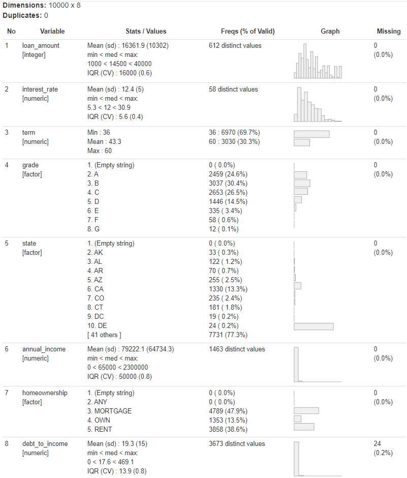

```r
summarytools::dfSummary(loans,
          plain.ascii  = FALSE,
          style        = "grid",
          graph.magnif = 0.75,
          valid.col    = FALSE,
          tmp.img.dir  = "/tmp")
```

Note: Using an image here (rather than output) for reasons that are too complicated to explain here.

### Categotical Variables

A typical summary of categorical data is a frequency table. One way to do this is via the `count` function.

```r
# frequency table of homeownership
loans |>
  count(homeownership)
```

| homeownership | n |
| --- | --- |
| MORTGAGE | 4789 |
| OWN | 1353 |
| RENT | 3858 |

**Action:**

In the designated location in the **A3_EDA_Template.Rmd** file, create a frequency table for `grade`.

## Multivariate Techniques

We can also find summary statistics for numerical variables and categorical variables by groups (a different categorical variable).

### Numerical Variables

To summarize numeric variables based on a categorical variable we can use the `group_by` function in `tidyverse`. In the following code we are calculating summary statistics for `loan_amount` for each `homeownership` category.

```r
loans |>
  group_by(homeownership) |>
  summarise(mean_loanAmt = mean(loan_amount),
            sd_loanAmt = sd(loan_amount),
            min_loanAmt = min(loan_amount),
            max_loanAmt = max(loan_amount),
            n = n()
            )
```

| homeownership | mean_loanAmt | sd_loanAmt | min_loanAmt | max_loanAmt | n |
| --- | --- | --- | --- | --- | --- |
| MORTGAGE | 18128.98 | 10650.144 | 1000 | 40000 | 4789 |
| OWN | 15683.92 | 10034.886 | 1000 | 40000 | 1353 |
| RENT | 14406.22 | 9548.247 | 1000 | 40000 | 3858 |

You can use group_by in other pipable functions as well…

```r
loans |>
  group_by(homeownership) |>
  rstatix::get_summary_stats(loan_amount, type = "mean_sd")
```

| homeownership | variable | n | mean | sd |
| --- | --- | --- | --- | --- |
| MORTGAGE | loan_amount | 4789 | 18128.98 | 10650.144 |
| OWN | loan_amount | 1353 | 15683.92 | 10034.886 |
| RENT | loan_amount | 3858 | 14406.22 | 9548.247 |

**Action:**

In the designated location in the **A3_EDA_Template.Rmd** file, create a summary statistics table for the following statistics grouped by `grade`

- median of `interest_rate`
- IQR (function `iqr()`) of `interest_rate`
- mean of `debt_to_income`
- standard deviation of `debt_to_income`

### Categorical Variables

Similary we can cross tabulate categorical variables using the `group_by` function.

```r
loans |>
  group_by(homeownership) |>
  count(homeownership)
```

| homeownership | n |
| --- | --- |
| MORTGAGE | 4789 |
| OWN | 1353 |
| RENT | 3858 |

**Action:**

In the designated location in the **A3_EDA_Template.Rmd** file, create a cross table of frequencies for `homeownership` by `grade`. (It doesn’t matter which is rows and which is columns)

## Resources:

- [IBM: What is exploratory data analysis (EDA)?](https://www.ibm.com/topics/exploratory-data-analysis)
- [Introduction to summarytools](https://cran.r-project.org/web/packages/summarytools/vignettes/introduction.html)